# Microglial morphology

Bindoff, A.

2017-08-29

```
##         strain
## agemonth tg wt
##       3  40 40
##       6  39 40
##       12 40 40
```

```
##       strain
## plaque  tg  wt
##    no   61 120
##    yes  58   0
```

```
##         strain
## location tg wt
##   away   59 60
##   plaque 60 60
```

For each cell morphology, a generalised linear mixed model was fitted with the proportion of cells with that morphology as the response variable, and location, strain, age, and strain x age interaction as predictors. Section was nested within animal as the random effects term. This is a random effect because sections are taken from animals which are drawn from a population, and the effect of each individual animal is random (not assigned or controlled). In each case, a violin plot is drawn. The bars show estimated mean and 95% CI. Data points are overlaid.

### Ramified

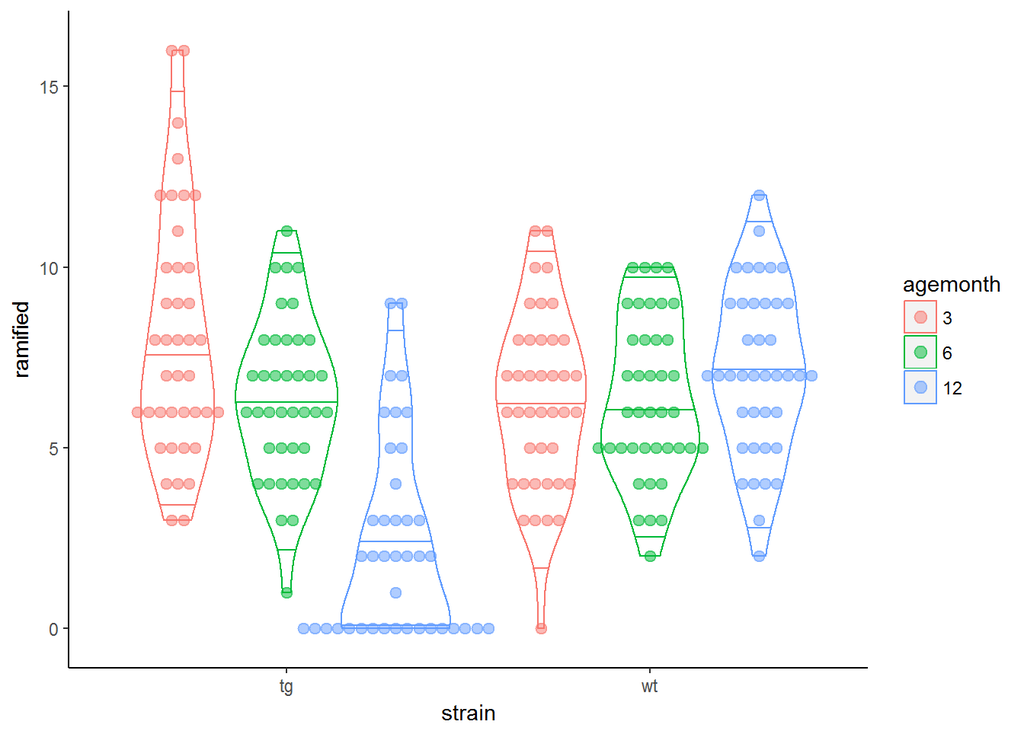

```
## Analysis of Deviance Table (Type III Wald chisquare tests)
##
## Response: cbind(ramified, totalcells)
##                    Chisq Df Pr(>Chisq)
## (Intercept)       0.0108  1    0.91719
## location         50.1232  1  1.444e-12 ***
## strain            6.1261  1    0.01332 *
## agemonth        206.2987  2  < 2.2e-16 ***
## strain:agemonth 140.0851  2  < 2.2e-16 ***
## ---
## Signif. codes:  0 '***' 0.001 '**' 0.01 '*' 0.05 '.' 0.1 ' ' 1
```

### Hyper-ramified

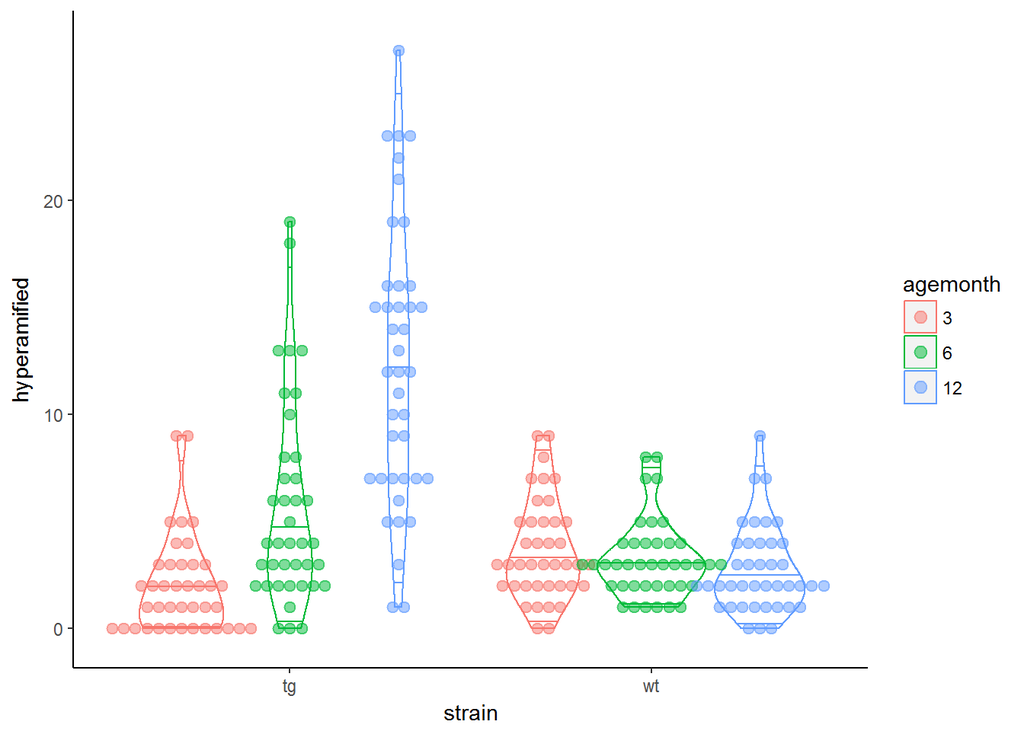

```
## Analysis of Deviance Table (Type III Wald chisquare tests)
##
## Response: cbind(hyperamified, totalcells)
##                   Chisq Df Pr(>Chisq)
## (Intercept)     207.261  1  < 2.2e-16 ***
## location         27.630  1  1.469e-07 ***
## strain           16.054  1  6.157e-05 ***
## agemonth         73.015  2  < 2.2e-16 ***
## strain:agemonth  50.553  2  1.053e-11 ***
## ---
## Signif. codes:  0 '***' 0.001 '**' 0.01 '*' 0.05 '.' 0.1 ' ' 1
```

### Amoeboid

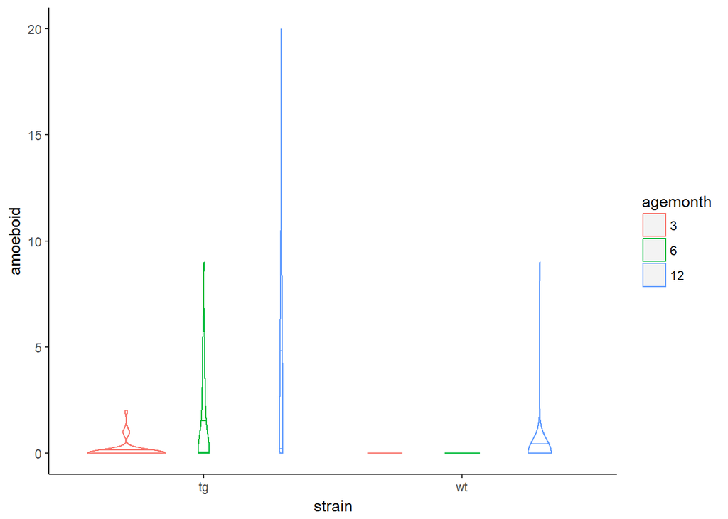

```
## Warning in checkConv(attr(opt, "derivs"), opt$par, ctrl = control
## $checkConv, : unable to evaluate scaled gradient
```

```
## Warning in checkConv(attr(opt, "derivs"), opt$par, ctrl = control
## $checkConv, : Model failed to converge: degenerate Hessian with 2 negative
## eigenvalues
```

The summary for this model includes a warning, and does not give much evidence for an interaction. We fit the model again without an interaction.

```
## Data: df
## Models:
## amoeboid2: cbind(amoeboid, totalcells) ~ location + strain + agemonth +
## amoeboid2:     (1 | animal/section)
## amoeboid1: cbind(amoeboid, totalcells) ~ location + strain * agemonth +
## amoeboid1:     (1 | animal/section)
##           Df    AIC    BIC  logLik deviance  Chisq Chi Df Pr(>Chisq)
## amoeboid2  7 333.73 358.07 -159.87   319.73
## amoeboid1  9 334.75 366.04 -158.37   316.75 2.9857      2     0.2247
```

A likelihood-ratio test (LRT) tells us that the models are equivalent (Pr(>Chisq) > .05), so there is no evidence to include the interaction term. We report these null results, and the results of the model without the interaction term.

```
## Analysis of Deviance Table (Type III Wald chisquare tests)
##
## Response: cbind(amoeboid, totalcells)
##              Chisq Df Pr(>Chisq)
## (Intercept) 65.466  1  5.913e-16 ***
## location    63.167  1  1.899e-15 ***
## strain      20.058  1  7.515e-06 ***
## agemonth    17.406  2  0.0001661 ***
## ---
## Signif. codes:  0 '***' 0.001 '**' 0.01 '*' 0.05 '.' 0.1 ' ' 1
```

### Rod

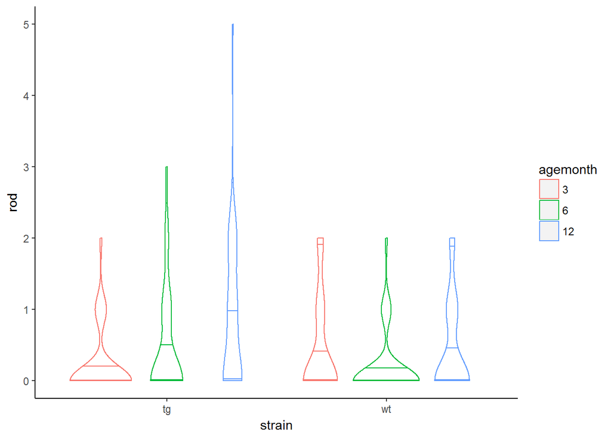

```
## Analysis of Deviance Table (Type III Wald chisquare tests)
##
## Response: cbind(rod, totalcells)
##                   Chisq Df Pr(>Chisq)
## (Intercept)     92.9971  1  < 2.2e-16 ***
## location        10.9097  1  0.0009566 ***
## strain           2.6730  1  0.1020623
## agemonth         4.0352  2  0.1329757
## strain:agemonth  4.5976  2  0.1003769
## ---
## Signif. codes:  0 '***' 0.001 '**' 0.01 '*' 0.05 '.' 0.1 ' ' 1
```

### Filtering on “plaque = no”

### Ramified - no plaque

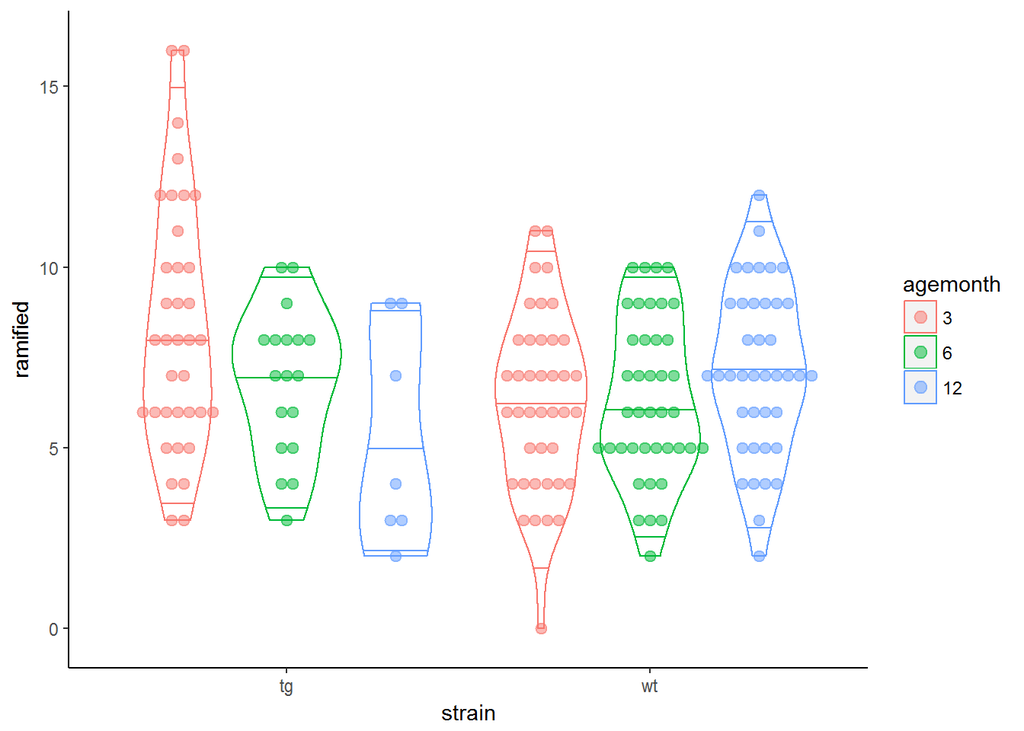

```
## Analysis of Deviance Table (Type III Wald chisquare tests)
##
## Response: cbind(ramified, totalcells)
##                   Chisq Df Pr(>Chisq)
## (Intercept)      2.0764  1  0.1495956
## location         5.0090  1  0.0252158 *
## strain           7.2066  1  0.0072635 **
## agemonth        16.6150  2  0.0002467 ***
## strain:agemonth 16.7405  2  0.0002317 ***
## ---
## Signif. codes:  0 '***' 0.001 '**' 0.01 '*' 0.05 '.' 0.1 ' ' 1
```

### Hyper-ramified - no plaque

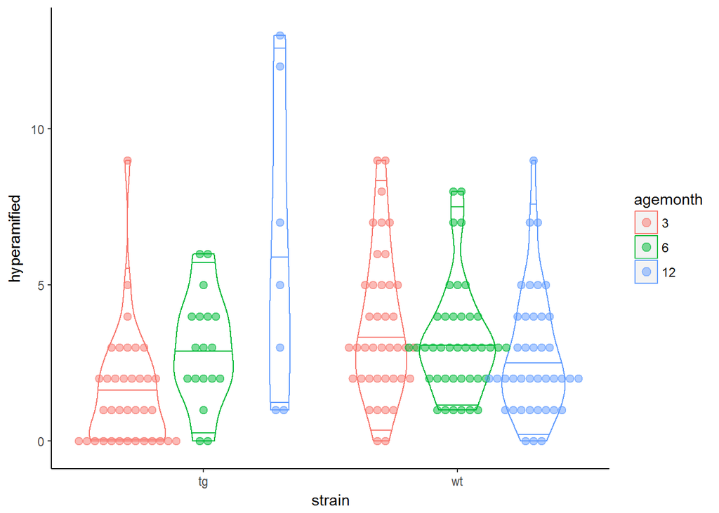

```
## Analysis of Deviance Table (Type III Wald chisquare tests)
##
## Response: cbind(hyperamified, totalcells)
##                   Chisq Df Pr(>Chisq)
## (Intercept)     160.023  1  < 2.2e-16 ***
## location         11.523  1  0.0006873 ***
## strain           19.321  1  1.105e-05 ***
## agemonth         25.610  2  2.747e-06 ***
## strain:agemonth  26.158  2  2.089e-06 ***
## ---
## Signif. codes:  0 '***' 0.001 '**' 0.01 '*' 0.05 '.' 0.1 ' ' 1
```

### Amoeboid - no plaque

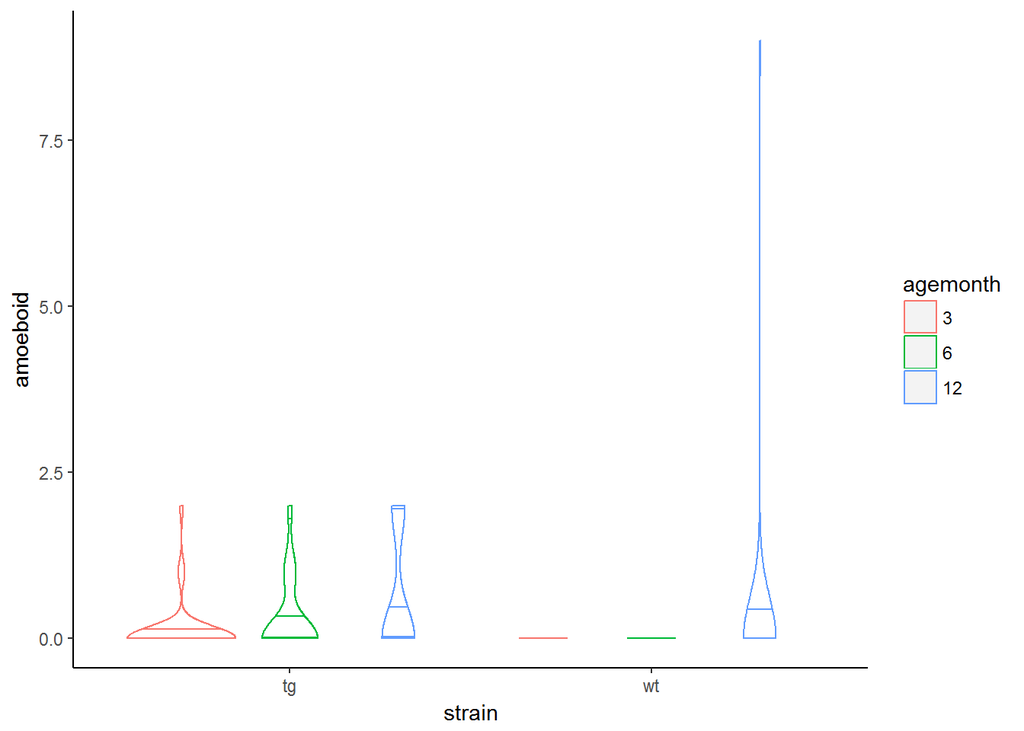

```
## Warning in checkConv(attr(opt, "derivs"), opt$par, ctrl = control
## $checkConv, : unable to evaluate scaled gradient
```

```
## Warning in checkConv(attr(opt, "derivs"), opt$par, ctrl = control
## $checkConv, : Hessian is numerically singular: parameters are not uniquely
## determined
```

The summary for this model includes a warning, and does not give much evidence for an interaction. We fit the model again without an interaction.

```
## Data: df
## Models:
## amoeboid2: cbind(amoeboid, totalcells) ~ location + strain + agemonth +
## amoeboid2:     (1 | animal/section)
## amoeboid1: cbind(amoeboid, totalcells) ~ location + strain * agemonth +
## amoeboid1:     (1 | animal/section)
##           Df    AIC    BIC  logLik deviance  Chisq Chi Df Pr(>Chisq)
## amoeboid2  7 106.32 128.71 -46.162   92.323
## amoeboid1  9 108.90 137.69 -45.451   90.901 1.4222      2     0.4911
```

A likelihood-ratio test (LRT) tells us that the models are equivalent (Pr(>Chisq) > .05), so there is no evidence to include the interaction term. We report these null results, and the results of the model without the interaction term.

```
## Analysis of Deviance Table (Type III Wald chisquare tests)
##
## Response: cbind(amoeboid, totalcells)
##               Chisq Df Pr(>Chisq)
## (Intercept) 27.8172  1  1.333e-07 ***
## location     2.6653  1   0.102558
## strain       7.5285  1   0.006073 **
## agemonth     4.4331  2   0.108986
## ---
## Signif. codes:  0 '***' 0.001 '**' 0.01 '*' 0.05 '.' 0.1 ' ' 1
```

### Rod

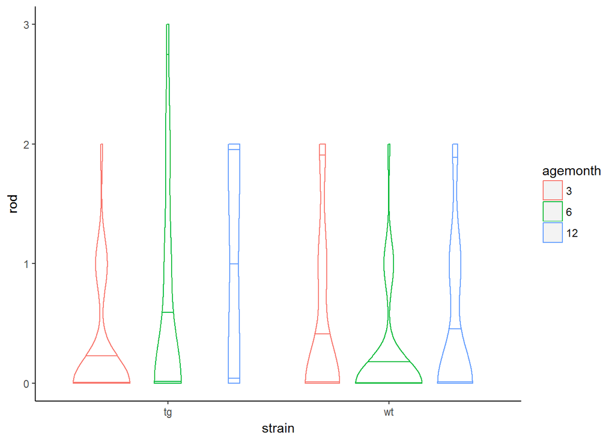

```
## Analysis of Deviance Table (Type III Wald chisquare tests)
##
## Response: cbind(rod, totalcells)
##                   Chisq Df Pr(>Chisq)
## (Intercept)     98.5524  1    < 2e-16 ***
## location         0.1037  1    0.74740
## strain           2.1135  1    0.14601
## agemonth         5.0423  2    0.08037 .
## strain:agemonth  6.5574  2    0.03768 *
## ---
## Signif. codes:  0 '***' 0.001 '**' 0.01 '*' 0.05 '.' 0.1 ' ' 1
```

### Suggestions

Location: this rings some pretty big alarm bells - what does it really signify? There were no plaques in wt mice. I’m not sure how to interpret the effect of location. This is why I ran a sub-analysis taking out “plaque = ‘yes’” mice.

Interaction terms: where there is a significant interaction, you should **not** interpret the main effects strain and age, even if significant. For the amoeboid morphologies, you can only interpret the main effects. So this means that the effect of age must be averaged over strain, and the effect of strain must be averaged over age.

Plots: tell me what you want. I like the stacked dot plots for this sort of count data, but they don’t really work when you’ve got a lot of zeros (they all run into each other) - hence the violin plots. However…

Because each section has a distribution of morphologies, I think plotting in a way that highlights these differences is useful:

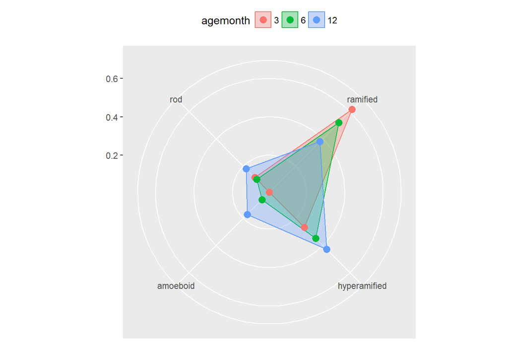

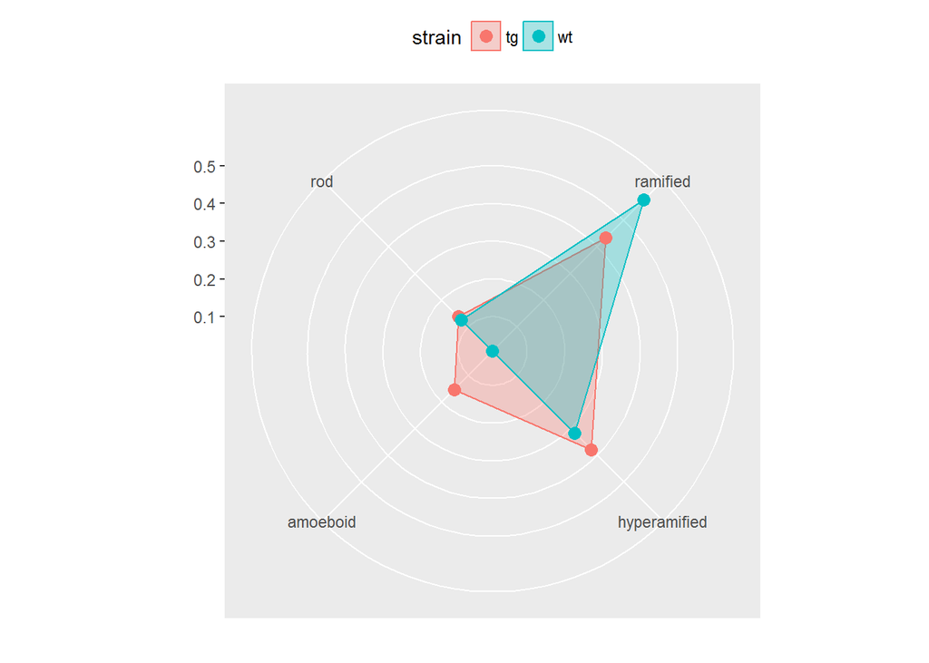

Descriptive statistics: let’s have a talk about how we deal with the location and plaque issues before we look at this.